# Entregable 3: Eliminación de Adaptadores, Control de Calidad y Alineamiento

Equipo 4 - Leonardo Ivan Anaya Gonzalez & Rubií Martínez Chavarría

2026-05-06

## Descripción del equipo

- **Equipo:** Equipo 4
- **Integrantes:**
  - Leonardo Ivan Anaya Gonzalez (lanaya)
  - Rubií Martínez Chavarría (rmartinez)
- **Correos electrónicos:** leoianayaglz@gmail.com | rubimarch201@gmail.com

## 1. Descripción de los datos

Tabla 1. Detalles del Bioproyecto GSE296420

[output not shown]

El artículo *“Altered hepatic metabolism in Down syndrome”* analiza las consecuencias metabólicas de la trisomía 21 en el hígado, usando un modelo murino Dp(16)1Yey (Dp16). Este modelo porta una duplicación del segmento del cromosoma 16 murino homólogo al cromosoma 21 humano. El estudio reporta niveles elevados de ácidos biliares, inflamación hepática, fibrosis y una reacción ductular en los ratones Dp16.

Para esta práctica se seleccionaron 6 muestras de tejido hepático: 3 wild-type (WT) y 3 Dp16.

Tabla 2. Muestras seleccionadas para el análisis diferencial.

| SRR | Condicion | Genotipo | Tejido | Replica |
| --- | --- | --- | --- | --- |
| SRR33445252 | Control (WT) | Wild-type C57BL/6J | Hígado | WT_1 |
| SRR33445253 | Control (WT) | Wild-type C57BL/6J | Hígado | WT_2 |
| SRR33445254 | Control (WT) | Wild-type C57BL/6J | Hígado | WT_3 |
| SRR33445260 | Tratamiento (Dp16) | Dp(16)1Yey | Hígado | Dp16_1 |
| SRR33445261 | Tratamiento (Dp16) | Dp(16)1Yey | Hígado | Dp16_2 |
| SRR33445262 | Tratamiento (Dp16) | Dp(16)1Yey | Hígado | Dp16_3 |

## 2. Control de calidad de datos crudos (FastQC y MultiQC)

Se analizó la calidad de las secuencias en los datos crudos mediante **FastQC** y la visualización conjunta con **MultiQC**, evaluando métricas como contenido de GC, profundidad de lectura, puntaje Phred y presencia de adaptadores.

### 2.2 Calidad de las lecturas por posición de base

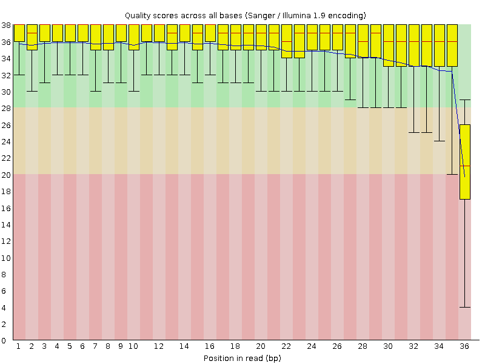

Figura 2. Calidad de las secuencias por posición de base.

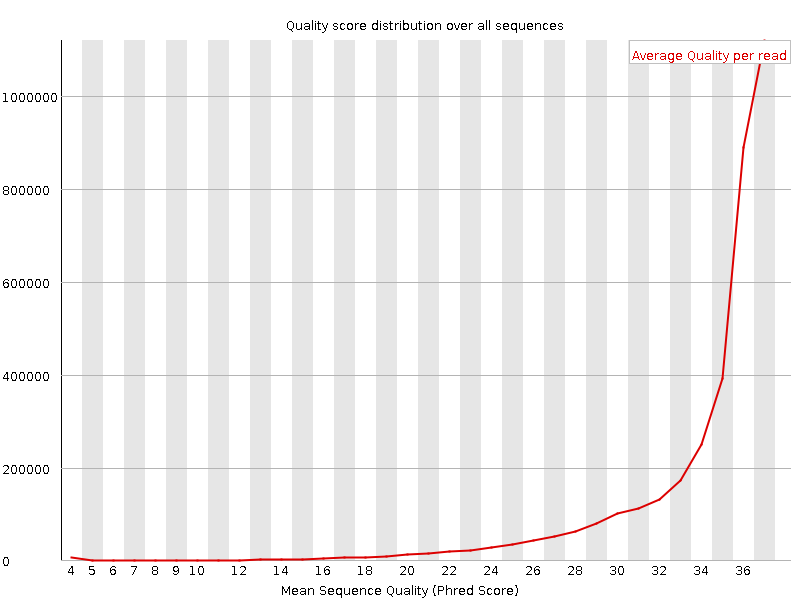

Figura 3. Distribución de puntajes de calidad por secuencia.

### 2.3 Contenido de GC

El contenido de GC esperado para tejido hepático de ratón es aproximadamente 50%. Variaciones en esta distribución pueden indicar contaminación o sesgo de amplificación.

### 2.4 Niveles de duplicación

Las secuencias duplicadas son comunes en RNA-seq debido a la alta expresión de ciertos genes. Un nivel moderado de duplicación es esperado y no necesariamente indica un problema.

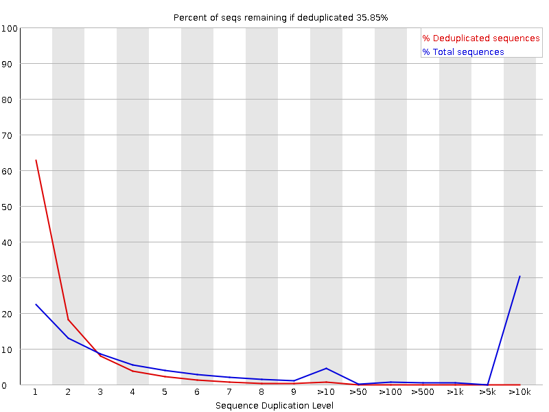

Figura 5. Niveles de duplicación de secuencias.

### 2.5 Contenido de adaptadores

Los adaptadores son secuencias añadidas durante la preparación de la librería que deben eliminarse antes del alineamiento. Se detectó la presencia de adaptadores **TruSeq3-PE** de Illumina en las muestras.

### 2.6 Conclusión sobre los datos crudos

Los datos crudos presentan una **calidad general óptima**:

- Puntaje Phred > 30 en prácticamente todas las posiciones
- Contenido de GC apropiado para tejido hepático murino
- Niveles de duplicación esperados para RNA-seq
- **Se detectaron adaptadores TruSeq3-PE** que deben eliminarse antes del alineamiento

**¿Son viables para continuar con el análisis?** Sí. Los datos son de buena calidad y viables para continuar, con la condición de eliminar los adaptadores y aplicar trimming de calidad antes del alineamiento.

**¿Qué pasos deben seguirse para mejorar la calidad?**

1. Eliminar los adaptadores TruSeq3-PE con Trimmomatic
2. Recortar bases de baja calidad (Phred < 20) en los extremos de las lecturas
3. Descartar lecturas que queden muy cortas después del trimming (< 36 bp)
4. Verificar la calidad nuevamente con FastQC/MultiQC post-trimming

## 3. Eliminación de adaptadores con Trimmomatic

### ¿Por qué hacemos trimming?

Las lecturas de RNA-seq pueden contener **adaptadores** al final — secuencias del protocolo de secuenciación que no provienen del organismo. Si no se eliminan, el alineador no podrá mapear esas lecturas correctamente porque buscará esas secuencias en el genoma y no las encontrará.

Además, las bases al inicio y al final suelen tener menor calidad (Phred bajo), por lo que también se recortan.

### Adaptadores utilizados

Se utilizaron los adaptadores **TruSeq3-PE** (Paired-End), correspondientes al kit de preparación de librerías de Illumina NovaSeq 6000 con selección PolyA. Descargados del repositorio oficial de Trimmomatic y guardados en: `/Users/dubsirubs/Desktop/RNAseq_Equipo4/adapters/TruSeq3-PE.fa`

### Script utilizado (SLURM job array)

El trimming se corrió como un **job array en SLURM** con 8 CPUs y 16GB de RAM por muestra:

```bash
#!/bin/bash
#SBATCH --job-name=trimmomatic_equipo4
#SBATCH --cpus-per-task=8
#SBATCH --mem=16G
#SBATCH --array=0-5

module load trimmomatic/0.33

trimmomatic PE \
    -threads 8 \
    -phred33 \
    ${SAMPLE}_1.fastq ${SAMPLE}_2.fastq \
    ${SAMPLE}_1_paired.fastq.gz   ${SAMPLE}_1_unpaired.fastq.gz \
    ${SAMPLE}_2_paired.fastq.gz   ${SAMPLE}_2_unpaired.fastq.gz \
    ILLUMINACLIP:TruSeq3-PE.fa:2:30:10 \
    LEADING:5 \
    TRAILING:5 \
    SLIDINGWINDOW:4:20 \
    MINLEN:36
```

**Outlogs:** `/Users/dubsirubs/Desktop/RNAseq_Equipo4/scripts/out_logs/trimmomatic_*`

### Resultados del trimming

Tabla 3. Resultados del trimming con Trimmomatic.

| Muestra | Grupo | Reads entrada | Both surviving | Dropped |
| --- | --- | --- | --- | --- |
| SRR33445252 | Control (WT) | 45,264,999 | 25,617,073 (56.59%) | 2.50% |
| SRR33445253 | Control (WT) | 43,357,474 | 25,779,245 (59.46%) | 2.51% |
| SRR33445254 | Control (WT) | 48,399,669 | 29,207,061 (60.35%) | 2.65% |
| SRR33445260 | Tratamiento (Dp16) | 50,327,443 | 30,054,674 (59.72%) | 2.44% |
| SRR33445261 | Tratamiento (Dp16) | 50,277,394 | 30,669,829 (61.00%) | 2.31% |
| SRR33445262 | Tratamiento (Dp16) | 51,227,777 | 31,712,682 (61.91%) | 2.45% |

En todas las muestras se descartó menos del **3%** de las lecturas.

### Control de calidad post-trimming (MultiQC)

Después del trimming se volvió a correr FastQC y MultiQC para verificar la eliminación de adaptadores.

**¿Se eliminaron los adaptadores?** Sí, tras aplicar Trimmomatic con los parámetros `ILLUMINACLIP:TruSeq3-PE.fa:2:30:10`, el contenido de adaptadores se redujo a cero en todas las muestras.

## 4. Diagrama de flujo del pipeline

El siguiente diagrama muestra el flujo completo del análisis desde los datos crudos hasta la importación en R:

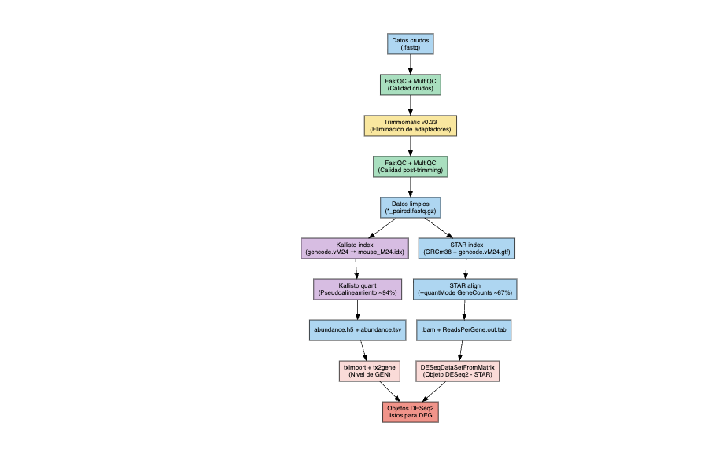

Figura 8. Diagrama de flujo del pipeline de RNA-seq.

[output not shown]

```r
library(rhdf5)

# Ruta a los resultados de Kallisto en el cluster
ruta <- "/Users/dubsirubs/Desktop/RNAseq_Equipo4/results_final/kallisto"

samples <- c("SRR33445252","SRR33445253","SRR33445254",
             "SRR33445260","SRR33445261","SRR33445262")

# Rutas a los archivos h5
archivos_h5 <- file.path(ruta, samples, "abundance.h5")
names(archivos_h5) <- samples

# Verificar archivos
print(archivos_h5)
```

```
##                                                                               SRR33445252
## "/Users/dubsirubs/Desktop/RNAseq_Equipo4/results_final/kallisto/SRR33445252/abundance.h5"
##                                                                               SRR33445253
## "/Users/dubsirubs/Desktop/RNAseq_Equipo4/results_final/kallisto/SRR33445253/abundance.h5"
##                                                                               SRR33445254
## "/Users/dubsirubs/Desktop/RNAseq_Equipo4/results_final/kallisto/SRR33445254/abundance.h5"
##                                                                               SRR33445260
## "/Users/dubsirubs/Desktop/RNAseq_Equipo4/results_final/kallisto/SRR33445260/abundance.h5"
##                                                                               SRR33445261
## "/Users/dubsirubs/Desktop/RNAseq_Equipo4/results_final/kallisto/SRR33445261/abundance.h5"
##                                                                               SRR33445262
## "/Users/dubsirubs/Desktop/RNAseq_Equipo4/results_final/kallisto/SRR33445262/abundance.h5"
```

```r
# Cargar tabla tx2gene generada desde Gencode vM24
# Mapea transcrito -> gen para agregar a nivel de gen
tx2gene <- read.csv("/Users/dubsirubs/Desktop/RNAseq_Equipo4/results_final/tx2gene_kallisto.csv")

# El formato de los target_id en kallisto es:
# ENSMUST00000193812.1|ENSMUSG00000102693.1|...|NombreGen|...
# tx2gene extrae solo TXNAME y GENEID
head(tx2gene)
```

```
##                 TXNAME               GENEID
## 1 ENSMUST00000193812.1 ENSMUSG00000102693.1
## 2 ENSMUST00000082908.1 ENSMUSG00000064842.1
## 3 ENSMUST00000162897.1 ENSMUSG00000051951.5
## 4 ENSMUST00000159265.1 ENSMUSG00000051951.5
## 5 ENSMUST00000070533.4 ENSMUSG00000051951.5
## 6 ENSMUST00000192857.1 ENSMUSG00000102851.1
```

```r
cat("Total transcritos en tx2gene:", nrow(tx2gene), "\n")
```

```
## Total transcritos en tx2gene: 142552
```

```r
# Cargar los metadatos
metadata <- read.csv("/Users/dubsirubs/Desktop/RNAseq_Equipo4/metadata.csv")

# Convertir genotype a factor con WT como referencia
metadata$genotype <- factor(metadata$genotype, levels = c("WT", "Dp16"))
rownames(metadata) <- metadata$sample

metadata
```

```
##                  sample genotype tissue
## SRR33445252 SRR33445252       WT  liver
## SRR33445253 SRR33445253       WT  liver
## SRR33445254 SRR33445254       WT  liver
## SRR33445260 SRR33445260     Dp16  liver
## SRR33445261 SRR33445261     Dp16  liver
## SRR33445262 SRR33445262     Dp16  liver
```

```r
# tximport con tx2gene agrega transcritos a nivel de GEN
# txOut = FALSE (default) -> nivel de gen
txi.kallisto <- tximport(archivos_h5,
                         type = "kallisto",
                         tx2gene = tx2gene,
                         txOut = FALSE,
                         ignoreTxVersion = FALSE,
                         ignoreAfterBar = TRUE)
```

```
## 1 2 3 4 5 6
## summarizing abundance
## summarizing counts
## summarizing length
```

```r
# Dimensiones de la matriz a nivel de gen
cat("Genes:", nrow(txi.kallisto$counts), "\n")
```

```
## Genes: 55385
```

```r
cat("Muestras:", ncol(txi.kallisto$counts), "\n")
```

```
## Muestras: 6
```

```r
head(txi.kallisto$counts)
```

```
##                       SRR33445252 SRR33445253 SRR33445254 SRR33445260
## ENSMUSG00000000001.4         1402        1746        1925        2242
## ENSMUSG00000000003.15           0           0           0           0
## ENSMUSG00000000028.15          42          46          31          35
## ENSMUSG00000000031.16          33          28          91          96
## ENSMUSG00000000037.17           3           0           1           1
## ENSMUSG00000000049.11       35910       35216       48769       50417
##                       SRR33445261 SRR33445262
## ENSMUSG00000000001.4         2558        2162
## ENSMUSG00000000003.15           0           0
## ENSMUSG00000000028.15          42          23
## ENSMUSG00000000031.16           9           8
## ENSMUSG00000000037.17           1           0
## ENSMUSG00000000049.11       55995       55722
```

```r
# Crear objeto DESeq2 desde tximport (nivel de gen)
dds <- DESeqDataSetFromTximport(txi.kallisto,
                                colData = metadata,
                                design = ~ genotype)
```

```
## using counts and average transcript lengths from tximport
```

```r
# Filtrar genes con pocas cuentas
# Mínimo 10 cuentas en al menos 3 muestras
keep <- rowSums(counts(dds) >= 10) >= 3
dds <- dds[keep,]

cat("Genes después del filtrado:", nrow(dds), "\n")
```

```
## Genes después del filtrado: 14715
```

```r
cat("Muestras:", ncol(dds), "\n")
```

```
## Muestras: 6
```

```r
dds
```

```
## class: DESeqDataSet
## dim: 14715 6
## metadata(1): version
## assays(2): counts avgTxLength
## rownames(14715): ENSMUSG00000000001.4 ENSMUSG00000000028.15 ...
##   ENSMUSG00000118631.1 ENSMUSG00000118633.1
## rowData names(0):
## colnames(6): SRR33445252 SRR33445253 ... SRR33445261 SRR33445262
## colData names(3): sample genotype tissue
```

### 6.2 Datos de STAR

**¿Por qué STAR genera cuentas directamente?** STAR con `--quantMode GeneCounts` cuenta las lecturas por gen directamente al genoma, por lo que no necesitamos tximport.

```r
# Directorio con resultados de STAR
star_dir <- "/Users/dubsirubs/Desktop/RNAseq_Equipo4/results_final/STAR"

samples <- c("SRR33445252","SRR33445253","SRR33445254",
             "SRR33445260","SRR33445261","SRR33445262")

# Leer cada archivo ReadsPerGene.out.tab
# skip = 4 salta las 4 primeras líneas de estadísticas generales
# columna 2 = cuentas unstranded
count_list <- lapply(samples, function(s) {
    f <- file.path(star_dir, s, paste0(s, ".ReadsPerGene.out.tab"))
    read.table(f, skip = 4, header = FALSE)[, c(1, 2)]
})

# Construir matriz
counts_star <- do.call(cbind, lapply(count_list, function(x) x[, 2]))
rownames(counts_star) <- count_list[[1]][, 1]
colnames(counts_star) <- samples

cat("Genes:", nrow(counts_star), "\n")
```

```
## Genes: 55385
```

```r
cat("Muestras:", ncol(counts_star), "\n")
```

```
## Muestras: 6
```

```r
head(counts_star)
```

```
##                      SRR33445252 SRR33445253 SRR33445254 SRR33445260
## ENSMUSG00000102693.1           0           0           0           0
## ENSMUSG00000064842.1           0           0           0           0
## ENSMUSG00000051951.5           0           0           0           0
## ENSMUSG00000102851.1           0           0           0           0
## ENSMUSG00000103377.1           0           0           0           0
## ENSMUSG00000104017.1           0           0           0           0
##                      SRR33445261 SRR33445262
## ENSMUSG00000102693.1           0           0
## ENSMUSG00000064842.1           0           0
## ENSMUSG00000051951.5           0           0
## ENSMUSG00000102851.1           0           0
## ENSMUSG00000103377.1           0           0
## ENSMUSG00000104017.1           0           0
```

```r
# Crear objeto DESeq2 desde matriz de STAR
dds_star <- DESeqDataSetFromMatrix(countData = counts_star,
                                   colData = metadata,
                                   design = ~ genotype)

# Filtrar genes con pocas cuentas
keep_star <- rowSums(counts(dds_star) >= 10) >= 3
dds_star <- dds_star[keep_star,]

cat("Genes después del filtrado:", nrow(dds_star), "\n")
```

```
## Genes después del filtrado: 14091
```

```r
cat("Muestras:", ncol(dds_star), "\n")
```

```
## Muestras: 6
```

```r
dds_star
```

```
## class: DESeqDataSet
## dim: 14091 6
## metadata(1): version
## assays(1): counts
## rownames(14091): ENSMUSG00000025902.13 ENSMUSG00000103922.1 ...
##   ENSMUSG00000064370.1 ENSMUSG00000064372.1
## rowData names(0):
## colnames(6): SRR33445252 SRR33445253 ... SRR33445261 SRR33445262
## colData names(3): sample genotype tissue
```

## 7. Conclusiones

*Documento generado con R Markdown. Análisis realizado en el cluster ken.lavis.unam.mx* *Ruta del proyecto: `/Users/dubsirubs/Desktop/RNAseq_Equipo4/`*